```python
from IPython.display import HTML

HTML('''<script>
code_show=true;
function code_toggle() {
 if (code_show){
 $('div.input').hide();
 } else {
 $('div.input').show();
 }
 code_show = !code_show
}
$( document ).ready(code_toggle);
</script>
<form action="javascript:code_toggle()"><input type="submit" value="Click here to toggle on/off the raw code."></form>''')
```

# AFRICAN SOIL PROPERTY PREDICTION

In this project, I build models to predict physical and chemical properties of soil using spectral measurements. The African Soil Property Prediction Dataset was obtained from kaggle website.

There are 5 target variables for prediction. These are:

- Ca - Mehlich-3 extractable Calcium
- P - Mehlich-3 extractable Phosphorus
- SOC - Soil organic carbon
- pH - pH values
- Sand - Sand content

The dataset is comprised of 1157 observations and 3600 columns. In addition to the 5 columns containing the targets, the other columns contain mid-infrared absorbance measurements of soil samples, and some spatial measurements obtained from remote sensing data sources. A brief description of the variables are provided below:

- PIDN - unique soil sample identifier
- m7497.96 - m599.76 - There are 3,578 mid-infrared absorbance measurements. For example, the "m7497.96" column is the absorbance at wavenumber 7497.96 cm-1.
- Depth - Depth of the soil sample (2 categories: "Topsoil", "Subsoil")
- BSA - average long-term Black Sky Albedo measurements from MODIS satellite images (BSAN = near-infrared, BSAS = shortwave, BSAV = visible)
- CTI - compound topographic index calculated from Shuttle Radar Topography Mission elevation data
- ELEV - Shuttle Radar Topography Mission elevation data
- EVI - average long-term Enhanced Vegetation Index from MODIS satellite images.
- LST - average long-term Land Surface Temperatures from MODIS satellite images (LSTD = day time temperature, LSTN = night time temperature)
- Ref - average long-term Reflectance measurements from MODIS satellite images (Ref1 = blue, Ref2 = red, Ref3 = near-infrared, Ref7 = mid-infrared)
- Reli - topographic Relief calculated from Shuttle Radar Topography mission elevation data TMAP & TMFI: average long-term Tropical Rainfall Monitoring Mission data (TMAP = mean annual precipitation, TMFI = modified Fournier index)

All the variables in this dataset are of data type float, except for Depth which is a categorical variable.

## Load Required Packages

I loaded the required packages for this project.

```python
## Load required packages
import pandas as pd
import numpy as np
from scipy import stats
from sklearn.model_selection import train_test_split
from pandas.tools.plotting import scatter_matrix
from sklearn import preprocessing
from sklearn.feature_selection import SelectKBest
from sklearn.feature_selection import f_regression
import matplotlib.pyplot as plt
from sklearn.linear_model import Ridge
from sklearn.svm import SVR
from sklearn.model_selection import learning_curve
from sklearn.metrics import mean_squared_error
from sklearn.metrics import explained_variance_score
from sklearn.metrics import mean_absolute_error
from sklearn.metrics import median_absolute_error
from sklearn.metrics import r2_score
% matplotlib inline
```

## Load and Split DataSet

I loaded in the data set, and split it into training, validation and testing set.

[output not shown]

```python
## Read in the data
pd.set_option('display.max_columns' , 40)
soil = pd.read_csv("/.../Datasets/africa_soil.csv")

## Split the data into train, test and validation
train, test = train_test_split(soil, test_size = 0.3, random_state = 19)
training, val = train_test_split(train, test_size = 0.3, random_state = 19)
```

## Exploratory Analysis

### Scatter Matrix and Correlation Matrix of the 5 Targets

I have made use of scatter plots and correlation matrix to explore the correlation between the 5 targets.

```python
## define the target cells
targets = training.iloc[:,range(3595,3600)]
```

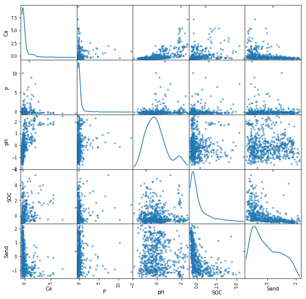

```python
# plot scatter matrix
scatter_matrix(targets, figsize=(10, 10), diagonal = 'kde')
plt.show()
```

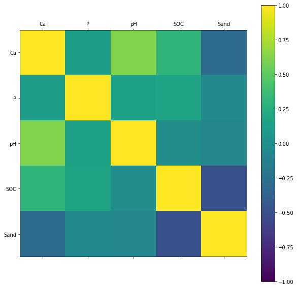

```python
# plot correlation matrix
correlations = targets.corr()
names = targets.columns
fig = plt.figure(figsize=(10, 10))
ax = fig.add_subplot(111)
cax = ax.matshow(correlations, vmin=-1, vmax=1)
fig.colorbar(cax)
ticks = np.arange(0,5,1)
ax.set_xticks(ticks)
ax.set_yticks(ticks)
ax.set_xticklabels(names)
ax.set_yticklabels(names)
plt.show()
```

Based on the plots above there are no strong correlations between any pair of targets; however, a slight positive correlation can be observed between Ca and pH, while a slight negative correlation can be observed between SOC and Sand. There are no good correlations between P and any other target.

### Visualizing the Mid-Infrared Absorbance Measurements

A sample mid-infrared spectra is provided below. The position and shape of the peaks in the spectra are used to identify some chemical and physical contents of the soil sample.

```python
IR_data = training.iloc[:, range(1,3579)]
IR_data = IR_data.transpose()
IR_data.reset_index(drop = False, inplace = True)
```

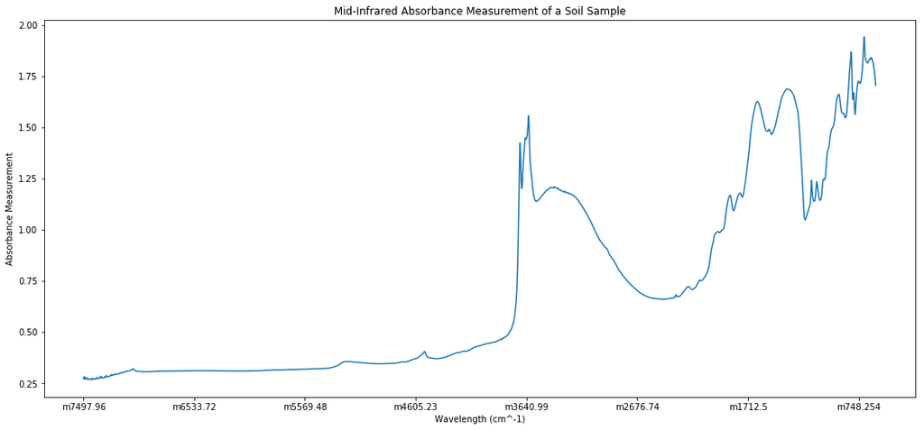

```python
fig = plt.figure(figsize=(18, 8))
x = IR_data.index
y = IR_data.iloc[:,1]
ax = fig.add_subplot(111)
ax.plot(x,y)
ticks = np.arange(0,3578,500)
names = IR_data['index'][ticks]
ax.set_xticks(ticks)
ax.set_xticklabels(names)
ax.set_xlabel('Wavelength (cm^-1)')
ax.set_ylabel('Absorbance Measurement')
ax.set_title('Mid-Infrared Absorbance Measurement of a Soil Sample')
plt.show()
```

### Exploring the correlation of soil depth with each of the targets

Boxplots have been used to show the distribution of the target values for topsoil and subsoil. As shown in the boxplots, the distribution of each target value appears to be similar regardless of soil depth. T-test were performed to validate this observation. The table of p-values below shows that, at a 95% confidence level, we fail to reject the null that the mean target values of Ca, pH, P differ across the soil depth. At a 95% confidence level, we reject the null in favor of the alternative that there is significant difference between the mean target values of SOC and Sand across the soil depth.

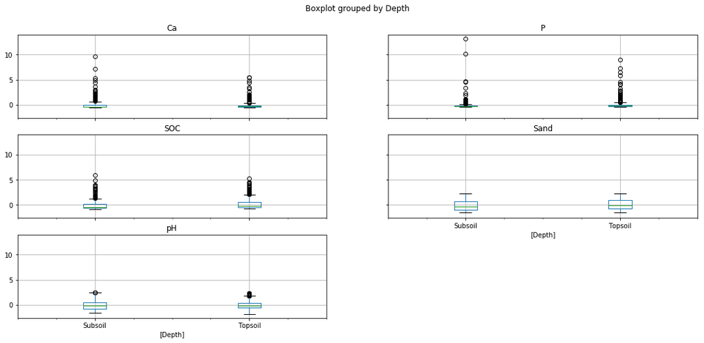

```python
depth_target = training[['Depth','Ca','P', 'pH', 'SOC', 'Sand']]
depth_target.boxplot(by='Depth', figsize=(18, 8))
plt.show()
```

```python
a = depth_target[depth_target['Depth'].str.contains('Subsoil') == True]['Ca']
b = depth_target[depth_target['Depth'].str.contains('Topsoil') == True]['Ca']
c = depth_target[depth_target['Depth'].str.contains('Subsoil') == True]['P']
d = depth_target[depth_target['Depth'].str.contains('Topsoil') == True]['P']
e = depth_target[depth_target['Depth'].str.contains('Subsoil') == True]['pH']
f = depth_target[depth_target['Depth'].str.contains('Topsoil') == True]['pH']
g = depth_target[depth_target['Depth'].str.contains('Subsoil') == True]['SOC']
h = depth_target[depth_target['Depth'].str.contains('Topsoil') == True]['SOC']
i = depth_target[depth_target['Depth'].str.contains('Subsoil') == True]['Sand']
j = depth_target[depth_target['Depth'].str.contains('Topsoil') == True]['Sand']

ttest1 = round(stats.ttest_ind(a,b, equal_var = False )[1], 2)
ttest2 = round(stats.ttest_ind(c,d, equal_var = False )[1], 2)
ttest3 = round(stats.ttest_ind(e,f, equal_var = False )[1], 2)
ttest4 = round(stats.ttest_ind(g,h, equal_var = False )[1], 2)
ttest5 = round(stats.ttest_ind(i,j, equal_var = False )[1], 2)

p_values = pd.DataFrame([['Ca',ttest1],['P', ttest2],['pH',ttest3],['SOC',ttest4],['Sand',ttest5] ], columns = ('Target','p-value'))
print(p_values)
```

```
  Target  p-value
0     Ca     0.17
1      P     0.07
2     pH     0.83
3    SOC     0.00
4   Sand     0.03
```

### Exploring the spatial predictors

Based on the low correlations of the spatial predictors with each of the target variables (as can be seen in the table below), I don't anticipate needing these predictors when building the prediction models. The higest correlations in the table below are between pH & EVI, and pH & LSTD. The scatter plots show the correlations. These variables (EVI and LSTD) may be useful in improving the prediction model of pH.

```python
spatial = training.iloc[:,range(3579,3594)]
spatial_target = spatial.join(targets)
```

```python
target_cols = ['Ca', 'P', 'pH', 'SOC', 'Sand']
corr = round(spatial_target.corr().filter(target_cols).drop(target_cols),3)
print(corr)
```

```
         Ca      P     pH    SOC   Sand
BSAN  0.020 -0.097  0.296 -0.261  0.280
BSAS  0.110 -0.084  0.380 -0.284  0.234
BSAV  0.254 -0.044  0.467 -0.255  0.120
CTI   0.064 -0.052  0.142 -0.210  0.172
ELEV  0.362  0.158  0.073  0.301 -0.339
EVI  -0.345 -0.025 -0.507  0.223 -0.064
LSTD  0.217 -0.041  0.507 -0.242  0.242
LSTN -0.339 -0.138 -0.129 -0.185  0.171
REF1  0.230 -0.049  0.444 -0.267  0.132
REF2 -0.228 -0.091 -0.170 -0.016  0.116
REF3  0.177 -0.068  0.340 -0.221  0.068
REF7  0.222 -0.042  0.493 -0.298  0.255
RELI  0.111  0.132 -0.141  0.393 -0.351
TMAP -0.227 -0.007 -0.487  0.385 -0.379
TMFI -0.244  0.011 -0.405  0.244 -0.268
```

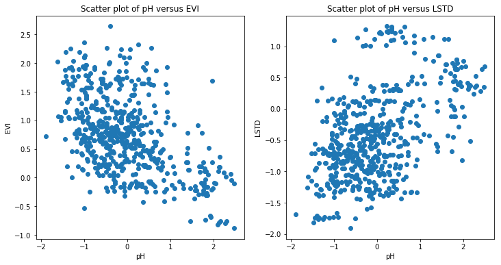

```python
fig = plt.figure(figsize=(12, 6))
ax = fig.add_subplot(121)
ax.scatter(spatial_target['pH'],y = spatial_target['EVI'])
ax.set_xlabel('pH')
ax.set_ylabel('EVI')
ax.set_title('Scatter plot of pH versus EVI')
ax2 = fig.add_subplot(122)
ax2.scatter(spatial_target['pH'],y = spatial_target['LSTD'])
ax2.set_xlabel('pH')
ax2.set_ylabel('LSTD')
ax2.set_title('Scatter plot of pH versus LSTD')
plt.show()
```

## Data Cleaning

I performed some data cleaning by dropping the soil identifier column 'PIDN' from both the training and validation sets. Then I performed label encoding on the column 'Depth' as follows:

- Subsoil - 0
- Topsoil - 1

```python
## Data Cleaning
training = training.drop('PIDN', 1)
val = val.drop('PIDN', 1)

## Label Encoding of Depth
le = preprocessing.LabelEncoder()
le.fit(training['Depth'])
training['Depth'] = le.transform(training['Depth'])
val['Depth'] = le.transform(val['Depth'])
```

## Feature Selection

I used SelectKBest function, with a f-regression scoring to select the k best wavelength mid-infrared measurements for the different targets. The value of k was dependent the number required to build the best predictive model for each target. I made use of 600 wavelength measurements for Ca, SOC and Sand, and 1000 for pH.

Then I defined the X variables for each target. The X variables for targets Ca, and pH only consisted of mid-infrared measurements. For targets SOC and Sand, in addition to mid-infrared measurements I included soil depth as predictors, since they both had significant correlation with soil depth as discussed earlier.

When building the models, I found no value in adding any of the spatial predictors as there did not improve the models.

```python
## subset the training targets for the different soil properties
training_Ca_y = training['Ca']
training_pH_y = training['pH']
training_SOC_y = training['SOC']
training_Sand_y = training['Sand']
training_P_y = training['P']

## Features Selection
IR_train = training.iloc[:, range(0,3579)]
IR_val = val.iloc[:, range(0,3579)]
depth_train = training['Depth']
depth_val = val['Depth']
depth_train = depth_train.reset_index(drop= True)
depth_val = depth_val.reset_index(drop= True)


## select K best features
selection_Ca = SelectKBest(f_regression, k=600)
selection_Ca.fit(IR_train,training_Ca_y)
selection_pH = SelectKBest(f_regression, k=1000)
selection_pH.fit(IR_train,training_pH_y)
selection_SOC = SelectKBest(f_regression, k=600)
selection_SOC.fit(IR_train,training_SOC_y)
selection_Sand = SelectKBest(f_regression, k=600)
selection_Sand.fit(IR_train,training_Sand_y)
selection_P = SelectKBest(f_regression, k=600)
selection_P.fit(IR_train,training_P_y)


IR_train_Ca = pd.DataFrame(selection_Ca.transform(IR_train))
IR_val_Ca = pd.DataFrame(selection_Ca.transform(IR_val))
IR_train_pH = pd.DataFrame(selection_pH.transform(IR_train))
IR_val_pH = pd.DataFrame(selection_pH.transform(IR_val))
IR_train_SOC = pd.DataFrame(selection_SOC.transform(IR_train))
IR_val_SOC = pd.DataFrame(selection_SOC.transform(IR_val))
IR_train_Sand = pd.DataFrame(selection_Sand.transform(IR_train))
IR_val_Sand = pd.DataFrame(selection_Sand.transform(IR_val))
IR_train_P = pd.DataFrame(selection_P.transform(IR_train))
IR_val_P = pd.DataFrame(selection_P.transform(IR_val))


training_Ca_X = IR_train_Ca
training_pH_X = IR_train_pH
training_SOC_X = IR_train_SOC.join(depth_train)
training_Sand_X = IR_train_Sand.join(depth_train)
training_P_X = IR_train_P


val_Ca_X = IR_val_Ca
val_pH_X = IR_val_pH
val_SOC_X = IR_val_SOC.join(depth_val)
val_Sand_X = IR_val_Sand.join(depth_val)
val_P_X = IR_val_P


val_Ca_y = val['Ca']
val_pH_y = val['pH']
val_SOC_y = val['SOC']
val_Sand_y = val['Sand']
val_P_y = val['P']


data_Ca_X = training_Ca_X.append(val_Ca_X)
data_pH_X = training_pH_X.append(val_pH_X)
data_SOC_X = training_SOC_X.append(val_SOC_X)
data_Sand_X = training_Sand_X.append(val_Sand_X)
data_P_X = training_P_X.append(val_P_X)


data_Ca_y = training_Ca_y.append(val_Ca_y)
data_pH_y = training_pH_y.append(val_pH_y)
data_SOC_y = training_SOC_y.append(val_SOC_y)
data_Sand_y = training_Sand_y.append(val_Sand_y)
data_P_y = training_P_y.append(val_P_y)
```

## Ridge Regression Models

I built ridge regression models for each target. The learning curves of the models are shown in the plots below. I was unable to build a ridge regression model for the target Phosphorus (P).

### LEARNING CURVES FOR THE RIDGE REGRESSION MODELS

```python
## Ridge Regression for Ca

RigR_Ca = Ridge(alpha=0.01, solver='auto', random_state=None)
RigR_Ca.fit(training_Ca_X, training_Ca_y)

## Learning Curve
def plot_curve_RigR_Ca():
    # instantiate
    RigR_Ca = Ridge(alpha=0.01, solver='auto', random_state=None)

    # fit
    X = data_Ca_X
    y = data_Ca_y
    RigR_Ca.fit(X, y)


    train_sizes, train_err, val_err = learning_curve(RigR_Ca, X, y, n_jobs=1, cv=100, train_sizes=np.linspace(.1, 1.0, 5), verbose=0,
                                                     scoring = "neg_mean_squared_error")

    train_err = abs(train_err)**0.5
    val_err = abs(val_err)**0.5

    train_err_mean = np.mean(train_err, axis=1)
    train_err_std = np.std(train_err, axis=1)
    val_err_mean = np.mean(val_err, axis=1)
    val_err_std = np.std(val_err, axis=1)

    plt.figure()
    plt.title("Ridge Regression Model for Ca")

    # plot the std deviation as a transparent range at each training set size
    plt.fill_between(train_sizes, train_err_mean - train_err_std, train_err_mean + train_err_std, alpha=0.1, color="r")
    plt.fill_between(train_sizes, val_err_mean - val_err_std, val_err_mean + val_err_std, alpha=0.1, color="g")

    # plot the average training and test score lines at each training set size
    plt.plot(train_sizes, train_err_mean, 'o-', color="r", label="Training score")
    plt.plot(train_sizes, val_err_mean, 'o-', color="g", label="Cross-validation score")

    plt.legend(loc='lower right')
    plt.xlabel("Training examples")
    plt.ylabel("Root Mean Squared Error")

    # box-like grid
    plt.grid()
    # sizes the window for readability and displays the plot
    # shows error from 0 to 1.1
    plt.ylim(-.1,1.1)
    plt.show()
```

```python
## Ridge Regression for pH

RigR_pH = Ridge(alpha=0.01, solver='auto', random_state=None)
RigR_pH.fit(training_pH_X, training_pH_y)

## Learning Curve
def plot_curve_RigR_pH():
    # instantiate
    RigR_pH = Ridge(alpha=0.01, solver='auto', random_state=None)

    # fit
    X = data_pH_X
    y = data_pH_y
    RigR_pH.fit(X, y)


    train_sizes, train_err, val_err = learning_curve(RigR_pH, X, y, n_jobs=1, cv=100, train_sizes=np.linspace(.1, 1.0, 5), verbose=0,
                                                     scoring = "neg_mean_squared_error")

    train_err = abs(train_err)**0.5
    val_err = abs(val_err)**0.5

    train_err_mean = np.mean(train_err, axis=1)
    train_err_std = np.std(train_err, axis=1)
    val_err_mean = np.mean(val_err, axis=1)
    val_err_std = np.std(val_err, axis=1)

    plt.figure()
    plt.title("Ridge Regression Model for pH")

    # plot the std deviation as a transparent range at each training set size
    plt.fill_between(train_sizes, train_err_mean - train_err_std, train_err_mean + train_err_std, alpha=0.1, color="r")
    plt.fill_between(train_sizes, val_err_mean - val_err_std, val_err_mean + val_err_std, alpha=0.1, color="g")

    # plot the average training and test score lines at each training set size
    plt.plot(train_sizes, train_err_mean, 'o-', color="r", label="Training score")
    plt.plot(train_sizes, val_err_mean, 'o-', color="g", label="Cross-validation score")

    plt.legend(loc='lower right')
    plt.xlabel("Training examples")
    plt.ylabel("Root Mean Squared Error")

    # box-like grid
    plt.grid()
    # sizes the window for readability and displays the plot
    # shows error from 0 to 1.1
    plt.ylim(-.1,1.1)
    plt.show()
```

```python
## Ridge Regression for SOC

RigR_SOC = Ridge(alpha=0.01, solver='auto', random_state=None)
RigR_SOC.fit(training_SOC_X, training_SOC_y)

## Learning Curve
def plot_curve_RigR_SOC():
    # instantiate
    RigR_SOC = Ridge(alpha=0.01, solver='auto', random_state=None)

    # fit
    X = data_SOC_X
    y = data_SOC_y
    RigR_SOC.fit(X, y)


    train_sizes, train_err, val_err = learning_curve(RigR_SOC, X, y, n_jobs=1, cv=100, train_sizes=np.linspace(.1, 1.0, 5), verbose=0,
                                                     scoring = "neg_mean_squared_error")

    train_err = abs(train_err)**0.5
    val_err = abs(val_err)**0.5

    train_err_mean = np.mean(train_err, axis=1)
    train_err_std = np.std(train_err, axis=1)
    val_err_mean = np.mean(val_err, axis=1)
    val_err_std = np.std(val_err, axis=1)

    plt.figure()
    plt.title("Ridge Regression for SOC")

    # plot the std deviation as a transparent range at each training set size
    plt.fill_between(train_sizes, train_err_mean - train_err_std, train_err_mean + train_err_std, alpha=0.1, color="r")
    plt.fill_between(train_sizes, val_err_mean - val_err_std, val_err_mean + val_err_std, alpha=0.1, color="g")

    # plot the average training and test score lines at each training set size
    plt.plot(train_sizes, train_err_mean, 'o-', color="r", label="Training score")
    plt.plot(train_sizes, val_err_mean, 'o-', color="g", label="Cross-validation score")

    plt.legend(loc='lower right')
    plt.xlabel("Training examples")
    plt.ylabel("Root Mean Squared Error")

    # box-like grid
    plt.grid()
    # sizes the window for readability and displays the plot
    # shows error from 0 to 1.1
    plt.ylim(-.1,1.1)
    plt.show()
```

```python
## Ridge Regression for Sand

RigR_Sand = Ridge(alpha=0.01, solver='auto', random_state=None)
RigR_Sand.fit(training_Sand_X, training_Sand_y)

## Learning Curve
def plot_curve_RigR_Sand():
    # instantiate
    RigR_Sand = Ridge(alpha=0.01, solver='auto', random_state=None)

    # fit
    X = data_Sand_X
    y = data_Sand_y
    RigR_Sand.fit(X, y)


    train_sizes, train_err, val_err = learning_curve(RigR_Sand, X, y, n_jobs=1, cv=100, train_sizes=np.linspace(.1, 1.0, 5), verbose=0,
                                                     scoring = "neg_mean_squared_error")

    train_err = abs(train_err)**0.5
    val_err = abs(val_err)**0.5

    train_err_mean = np.mean(train_err, axis=1)
    train_err_std = np.std(train_err, axis=1)
    val_err_mean = np.mean(val_err, axis=1)
    val_err_std = np.std(val_err, axis=1)

    plt.figure()
    plt.title("Ridge Regression for Sand")

    # plot the std deviation as a transparent range at each training set size
    plt.fill_between(train_sizes, train_err_mean - train_err_std, train_err_mean + train_err_std, alpha=0.1, color="r")
    plt.fill_between(train_sizes, val_err_mean - val_err_std, val_err_mean + val_err_std, alpha=0.1, color="g")

    # plot the average training and test score lines at each training set size
    plt.plot(train_sizes, train_err_mean, 'o-', color="r", label="Training score")
    plt.plot(train_sizes, val_err_mean, 'o-', color="g", label="Cross-validation score")

    plt.legend(loc='lower right')
    plt.xlabel("Training examples")
    plt.ylabel("Root Mean Squared Error")

    # box-like grid
    plt.grid()
    # sizes the window for readability and displays the plot
    # shows error from 0 to 1.1
    plt.ylim(-.1,1.1)
    plt.show()
```

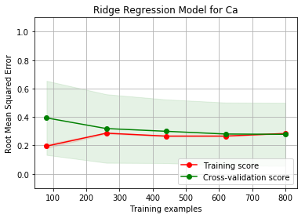

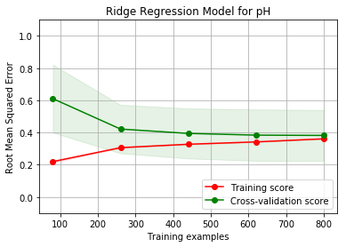

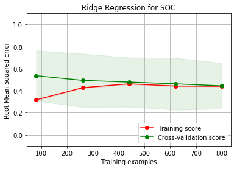

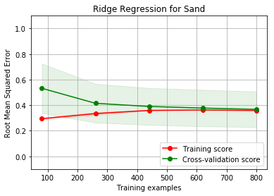

```python
## plot the learning curves for ridge regression model
plot_curve_RigR_Ca()
plot_curve_RigR_pH()
plot_curve_RigR_SOC()
plot_curve_RigR_Sand()
```

## Support Vector Regressor Models

I built support vector regressor models for each target. The learning curves of the models are shown in the plots below. I was unable to build a support vector regressor model for the target Phosphorus (P).

### LEARNING CURVES FOR SUPPORT VECTOR REGRESSOR MODELS

```python
## Support Vector Machine Regressor Model for Ca

SVR_Ca = SVR(kernel='linear', gamma='auto', C=100, epsilon=0.1)
SVR_Ca.fit(training_Ca_X, training_Ca_y)

## Learning Curve
def plot_curve_SVR_Ca():
    # instantiate
    SVR_Ca = SVR(kernel='linear', gamma='auto', C=100, epsilon=0.1)

    # fit
    X = data_Ca_X
    y = data_Ca_y
    SVR_Ca.fit(X, y)


    train_sizes, train_err, val_err = learning_curve(SVR_Ca, X, y, n_jobs=1, cv=2, train_sizes=np.linspace(.1, 1.0, 5), verbose=0,
                                                     scoring = "neg_mean_squared_error")

    train_err = abs(train_err)**0.5
    val_err = abs(val_err)**0.5

    train_err_mean = np.mean(train_err, axis=1)
    train_err_std = np.std(train_err, axis=1)
    val_err_mean = np.mean(val_err, axis=1)
    val_err_std = np.std(val_err, axis=1)

    plt.figure()
    plt.title("Support Vector Machine Regressor for Ca")

    # plot the std deviation as a transparent range at each training set size
    plt.fill_between(train_sizes, train_err_mean - train_err_std, train_err_mean + train_err_std, alpha=0.1, color="r")
    plt.fill_between(train_sizes, val_err_mean - val_err_std, val_err_mean + val_err_std, alpha=0.1, color="g")

    # plot the average training and test score lines at each training set size
    plt.plot(train_sizes, train_err_mean, 'o-', color="r", label="Training score")
    plt.plot(train_sizes, val_err_mean, 'o-', color="g", label="Cross-validation score")

    plt.legend(loc='lower right')
    plt.xlabel("Training examples")
    plt.ylabel("Root Mean Squared Error")

    # box-like grid
    plt.grid()
    # sizes the window for readability and displays the plot
    # shows error from 0 to 1.1
    plt.ylim(-.1,1.1)
    plt.show()
```

```python
## Support Vector Machine Regressor Model for pH

SVR_pH = SVR(kernel='linear', gamma='auto', C=200, epsilon=0.1)
SVR_pH.fit(training_pH_X, training_pH_y)

## Learning Curve
def plot_curve_SVR_pH():
    # instantiate
    SVR_pH = SVR(kernel='linear', gamma='auto', C=200, epsilon=0.1)

    # fit
    X = data_pH_X
    y = data_pH_y
    SVR_pH.fit(X, y)


    train_sizes, train_err, val_err = learning_curve(SVR_pH, X, y, n_jobs=1, cv=2, train_sizes=np.linspace(.1, 1.0, 5), verbose=0,
                                                     scoring = "neg_mean_squared_error")

    train_err = abs(train_err)**0.5
    val_err = abs(val_err)**0.5

    train_err_mean = np.mean(train_err, axis=1)
    train_err_std = np.std(train_err, axis=1)
    val_err_mean = np.mean(val_err, axis=1)
    val_err_std = np.std(val_err, axis=1)

    plt.figure()
    plt.title("Support Vector Machine Regressor for pH")

    # plot the std deviation as a transparent range at each training set size
    plt.fill_between(train_sizes, train_err_mean - train_err_std, train_err_mean + train_err_std, alpha=0.1, color="r")
    plt.fill_between(train_sizes, val_err_mean - val_err_std, val_err_mean + val_err_std, alpha=0.1, color="g")

    # plot the average training and test score lines at each training set size
    plt.plot(train_sizes, train_err_mean, 'o-', color="r", label="Training score")
    plt.plot(train_sizes, val_err_mean, 'o-', color="g", label="Cross-validation score")

    plt.legend(loc='lower right')
    plt.xlabel("Training examples")
    plt.ylabel("Root Mean Squared Error")

    # box-like grid
    plt.grid()
    # sizes the window for readability and displays the plot
    # shows error from 0 to 1.1
    plt.ylim(-.1,1.1)
    plt.show()
```

```python
## Support Vector Machine Regressor Model for SOC

SVR_SOC = SVR(kernel='linear', gamma='auto', C=200, epsilon=0.1)
SVR_SOC.fit(training_SOC_X, training_SOC_y)

## Learning Curve
def plot_curve_SVR_SOC():
    # instantiate
    SVR_SOC = SVR(kernel='linear', gamma='auto', C=200, epsilon=0.1)

    # fit
    X = data_SOC_X
    y = data_SOC_y
    SVR_SOC.fit(X, y)


    train_sizes, train_err, val_err = learning_curve(SVR_SOC, X, y, n_jobs=1, cv=2, train_sizes=np.linspace(.1, 1.0, 5), verbose=0,
                                                     scoring = "neg_mean_squared_error")

    train_err = abs(train_err)**0.5
    val_err = abs(val_err)**0.5

    train_err_mean = np.mean(train_err, axis=1)
    train_err_std = np.std(train_err, axis=1)
    val_err_mean = np.mean(val_err, axis=1)
    val_err_std = np.std(val_err, axis=1)

    plt.figure()
    plt.title("Support Vector Machine Regressor for SOC")

    # plot the std deviation as a transparent range at each training set size
    plt.fill_between(train_sizes, train_err_mean - train_err_std, train_err_mean + train_err_std, alpha=0.1, color="r")
    plt.fill_between(train_sizes, val_err_mean - val_err_std, val_err_mean + val_err_std, alpha=0.1, color="g")

    # plot the average training and test score lines at each training set size
    plt.plot(train_sizes, train_err_mean, 'o-', color="r", label="Training score")
    plt.plot(train_sizes, val_err_mean, 'o-', color="g", label="Cross-validation score")

    plt.legend(loc='lower right')
    plt.xlabel("Training examples")
    plt.ylabel("Root Mean Squared Error")

    # box-like grid
    plt.grid()
    # sizes the window for readability and displays the plot
    # shows error from 0 to 1.1
    plt.ylim(-.1,1.1)
    plt.show()
```

```python
## Support Vector Machine Regressor Model for Sand

SVR_Sand = SVR(kernel='rbf', gamma='auto', C=200, epsilon=0.1)
SVR_Sand.fit(training_Sand_X, training_Sand_y)

## Learning Curve
def plot_curve_SVR_Sand():
    # instantiate
    SVR_Sand = SVR(kernel='rbf', gamma='auto', C=200, epsilon=0.1)

    # fit
    X = data_Sand_X
    y = data_Sand_y
    SVR_Sand.fit(X, y)


    train_sizes, train_err, val_err = learning_curve(SVR_Sand, X, y, n_jobs=1, cv=2, train_sizes=np.linspace(.1, 1.0, 5), verbose=0,
                                                     scoring = "neg_mean_squared_error")

    train_err = abs(train_err)**0.5
    val_err = abs(val_err)**0.5

    train_err_mean = np.mean(train_err, axis=1)
    train_err_std = np.std(train_err, axis=1)
    val_err_mean = np.mean(val_err, axis=1)
    val_err_std = np.std(val_err, axis=1)

    plt.figure()
    plt.title("Support Vector Machine Regressor for Sand")

    # plot the std deviation as a transparent range at each training set size
    plt.fill_between(train_sizes, train_err_mean - train_err_std, train_err_mean + train_err_std, alpha=0.1, color="r")
    plt.fill_between(train_sizes, val_err_mean - val_err_std, val_err_mean + val_err_std, alpha=0.1, color="g")

    # plot the average training and test score lines at each training set size
    plt.plot(train_sizes, train_err_mean, 'o-', color="r", label="Training score")
    plt.plot(train_sizes, val_err_mean, 'o-', color="g", label="Cross-validation score")

    plt.legend(loc='lower right')
    plt.xlabel("Training examples")
    plt.ylabel("Root Mean Squared Error")

    # box-like grid
    plt.grid()
    # sizes the window for readability and displays the plot
    # shows error from 0 to 1.1
    plt.ylim(-.1,1.1)
    plt.show()
```

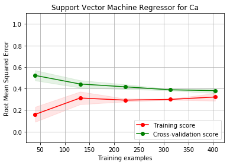

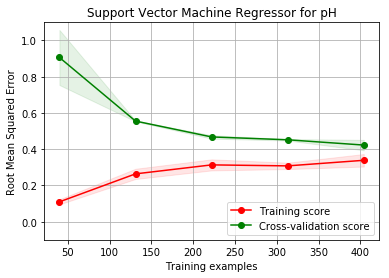

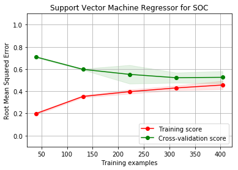

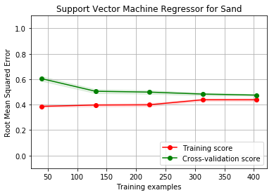

```python
## plot learning curves for support vector regressor model
plot_curve_SVR_Ca()
plot_curve_SVR_pH()
plot_curve_SVR_SOC()
plot_curve_SVR_Sand()
```

### Prediction Model for P

After several failed attempts to build a prediction model for P using the available predictors, I concluded that no good model can be built. This means that the available predictors (i.e. infrared spectra, and spatial measurements) have insufficient correlation with P. In the exploratory analysis, it was observed that P had no correlation with any of the other targets. This supports the conclusion that a different group of predictors will be required to build a prediction model for P.

## Model Selection

### PLOTS SHOWING MODEL COMPARISON FOR EACH TARGET

```python
## Clean and format the test data, in the same format as the training set.
test = test.drop('PIDN', 1)
test['Depth'] = le.transform(test['Depth'])


IR_test = test.iloc[:,range(0,3579)]
depth_test = test['Depth']
depth_test = depth_test.reset_index(drop= True)


IR_test_Ca = pd.DataFrame(selection_Ca.transform(IR_test))
IR_test_pH = pd.DataFrame(selection_pH.transform(IR_test))
IR_test_SOC = pd.DataFrame(selection_SOC.transform(IR_test))
IR_test_Sand = pd.DataFrame(selection_Sand.transform(IR_test))

test_Ca_X = IR_test_Ca
test_pH_X = IR_test_pH
test_SOC_X = IR_test_SOC.join(depth_test)
test_Sand_X = IR_test_Sand.join(depth_test)


test_Ca_y = test['Ca']
test_pH_y = test['pH']
test_SOC_y = test['SOC']
test_Sand_y = test['Sand']
```

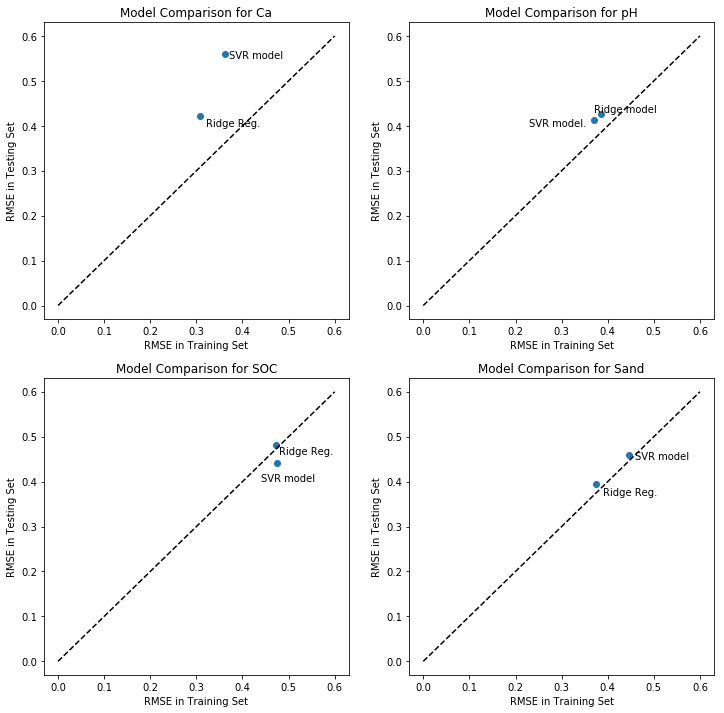

```python
## Comparing the models for Ca
RigR_Ca_pred_train = RigR_Ca.predict(data_Ca_X)
RigR_Ca_pred_test = RigR_Ca.predict(test_Ca_X)
SVR_Ca_pred_train = SVR_Ca.predict(data_Ca_X)
SVR_Ca_pred_test = SVR_Ca.predict(test_Ca_X)
## Comparing the models for pH
RigR_pH_pred_train = RigR_pH.predict(data_pH_X)
RigR_pH_pred_test = RigR_pH.predict(test_pH_X)
SVR_pH_pred_train = SVR_pH.predict(data_pH_X)
SVR_pH_pred_test = SVR_pH.predict(test_pH_X)
## Comparing the models for SOC
RigR_SOC_pred_train = RigR_SOC.predict(data_SOC_X)
RigR_SOC_pred_test = RigR_SOC.predict(test_SOC_X)
SVR_SOC_pred_train = SVR_SOC.predict(data_SOC_X)
SVR_SOC_pred_test = SVR_SOC.predict(test_SOC_X)
## Comparing the models for Sand
RigR_Sand_pred_train = RigR_Sand.predict(data_Sand_X)
RigR_Sand_pred_test = RigR_Sand.predict(test_Sand_X)
SVR_Sand_pred_train = SVR_Sand.predict(data_Sand_X)
SVR_Sand_pred_test = SVR_Sand.predict(test_Sand_X)



## RMSE of train and test set for Ca
a = mean_squared_error(data_Ca_y, RigR_Ca_pred_train)**0.5
b = mean_squared_error(test_Ca_y, RigR_Ca_pred_test)**0.5
c = mean_squared_error(data_Ca_y, SVR_Ca_pred_train)**0.5
d = mean_squared_error(test_Ca_y, SVR_Ca_pred_test)**0.5
RMSE_Summary_Ca = pd.DataFrame([['Ridge Regression',a,b],['Support Vector Regressor',c,d]], columns = ('Model', 'RMSE in Training Set','RMSE in Testing Set'))

## RMSE of train and test set for pH
e = mean_squared_error(data_pH_y, RigR_pH_pred_train)**0.5
f = mean_squared_error(test_pH_y, RigR_pH_pred_test)**0.5
g = mean_squared_error(data_pH_y, SVR_pH_pred_train)**0.5
h = mean_squared_error(test_pH_y, SVR_pH_pred_test)**0.5
RMSE_Summary_pH = pd.DataFrame([['Ridge Regression',e,f],['Support Vector Regressor',g,h]], columns = ('Model', 'RMSE in Training Set','RMSE in Testing Set'))

## RMSE of train and test set for SOC
i = mean_squared_error(data_SOC_y, RigR_SOC_pred_train)**0.5
j = mean_squared_error(test_SOC_y, RigR_SOC_pred_test)**0.5
k = mean_squared_error(data_SOC_y, SVR_SOC_pred_train)**0.5
l = mean_squared_error(test_SOC_y, SVR_SOC_pred_test)**0.5
RMSE_Summary_SOC = pd.DataFrame([['Ridge Regression',i,j],['Support Vector Regressor',k,l]], columns = ('Model', 'RMSE in Training Set','RMSE in Testing Set'))

## RMSE of train and test set for Sand
m = mean_squared_error(data_Sand_y, RigR_Sand_pred_train)**0.5
n = mean_squared_error(test_Sand_y, RigR_Sand_pred_test)**0.5
o = mean_squared_error(data_Sand_y, SVR_Sand_pred_train)**0.5
p = mean_squared_error(test_Sand_y, SVR_Sand_pred_test)**0.5
RMSE_Summary_Sand = pd.DataFrame([['Ridge Regression',m,n],['Support Vector Regressor',o,p]], columns = ('Model', 'RMSE in Training Set','RMSE in Testing Set'))

## Plots to visualize the model comparisons
fig = plt.figure(figsize=(12, 12))
ax = fig.add_subplot(221)
ax.scatter(RMSE_Summary_Ca['RMSE in Training Set'], RMSE_Summary_Ca['RMSE in Testing Set'])
ax.plot((0, 0.6), (0, 0.6), ls = "--", c="black")
ax.set_title('Model Comparison for Ca')
ax.set_xlabel('RMSE in Training Set')
ax.set_ylabel('RMSE in Testing Set')
plt.text(0.32,0.4, 'Ridge Reg.')
plt.text(0.37,0.55, 'SVR model')

ax2 = fig.add_subplot(222)
ax2.scatter(RMSE_Summary_pH['RMSE in Training Set'], RMSE_Summary_pH['RMSE in Testing Set'])
ax2.plot((0, 0.6), (0, 0.6), ls = "--", c="black")
ax2.set_title('Model Comparison for pH')
ax2.set_xlabel('RMSE in Training Set')
ax2.set_ylabel('RMSE in Testing Set')
plt.text(0.23,0.4, 'SVR model.')
plt.text(0.37,0.43, 'Ridge model')

ax3 = fig.add_subplot(223)
ax3.scatter(RMSE_Summary_SOC['RMSE in Training Set'], RMSE_Summary_SOC['RMSE in Testing Set'])
ax3.plot((0, 0.6), (0, 0.6), ls = "--", c="black")
ax3.set_title('Model Comparison for SOC')
ax3.set_xlabel('RMSE in Training Set')
ax3.set_ylabel('RMSE in Testing Set')
plt.text(0.48,0.46, 'Ridge Reg.')
plt.text(0.44,0.4, 'SVR model')

ax4 = fig.add_subplot(224)
ax4.scatter(RMSE_Summary_Sand['RMSE in Training Set'], RMSE_Summary_Sand['RMSE in Testing Set'])
ax4.plot((0, 0.6), (0, 0.6), ls = "--", c="black")
ax4.set_title('Model Comparison for Sand')
ax4.set_xlabel('RMSE in Training Set')
ax4.set_ylabel('RMSE in Testing Set')
plt.text(0.39,0.37, 'Ridge Reg.')
plt.text(0.46,0.45, 'SVR model')

plt.show()
```

## Model Metrics

The table below summarizes the estimated out-of-sample errors and other metrics score for the chosen models.

```python
## Explained variance score
EVS_Ca = round(explained_variance_score(test_Ca_y, RigR_Ca_pred_test),2)
EVS_pH = round(explained_variance_score(test_pH_y, SVR_pH_pred_test),2)
EVS_SOC = round(explained_variance_score(test_SOC_y, RigR_SOC_pred_test),2)
EVS_Sand = round(explained_variance_score(test_Sand_y, RigR_Sand_pred_test),2)

## RMSE
RMSE_Ca = round(mean_squared_error(test_Ca_y, RigR_Ca_pred_test)**0.5,2)
RMSE_pH = round(mean_squared_error(test_pH_y, SVR_pH_pred_test)**0.5,2)
RMSE_SOC = round(mean_squared_error(test_SOC_y, RigR_SOC_pred_test)**0.5,2)
RMSE_Sand = round(mean_squared_error(test_Sand_y, RigR_Sand_pred_test)**0.5,2)

## Mean Absolute Error
MAE_Ca = round(mean_absolute_error(test_Ca_y, RigR_Ca_pred_test),2)
MAE_pH = round(mean_absolute_error(test_pH_y, SVR_pH_pred_test),2)
MAE_SOC = round(mean_absolute_error(test_SOC_y, RigR_SOC_pred_test),2)
MAE_Sand = round(mean_absolute_error(test_Sand_y, RigR_Sand_pred_test),2)

## Median Absolute Error
Med_AE_Ca = round(median_absolute_error(test_Ca_y, RigR_Ca_pred_test),2)
Med_AE_pH = round(median_absolute_error(test_pH_y, SVR_pH_pred_test),2)
Med_AE_SOC = round(median_absolute_error(test_SOC_y, RigR_SOC_pred_test),2)
Med_AE_Sand = round(median_absolute_error(test_Sand_y, RigR_Sand_pred_test),2)

## R-squared score
R_sq_Ca = round(r2_score(test_Ca_y, RigR_Ca_pred_test),2)
R_sq_pH = round(r2_score(test_pH_y, SVR_pH_pred_test),2)
R_sq_SOC = round(r2_score(test_SOC_y, RigR_SOC_pred_test),2)
R_sq_Sand = round(r2_score(test_Sand_y, RigR_Sand_pred_test),2)



metric = pd.DataFrame([['Explained Variance Score', EVS_Ca, EVS_pH, EVS_SOC, EVS_Sand],['Mean Absolute Error', MAE_Ca, MAE_pH, MAE_SOC, MAE_Sand],['Root Mean Squared Error', RMSE_Ca, RMSE_pH, RMSE_SOC, RMSE_Sand],
              ['Median Absolute Error', Med_AE_Ca, Med_AE_pH, Med_AE_SOC, Med_AE_Sand], ['R_squared Score', R_sq_Ca, R_sq_pH, R_sq_SOC, R_sq_Sand]], columns=('Metric','Ca','pH','SOC','Sand'))
print(metric)
```

```
                     Metric    Ca    pH   SOC  Sand
0  Explained Variance Score  0.87  0.81  0.80  0.83
1       Mean Absolute Error  0.18  0.29  0.31  0.30
2   Root Mean Squared Error  0.42  0.41  0.48  0.39
3     Median Absolute Error  0.09  0.20  0.22  0.23
4           R_squared Score  0.87  0.81  0.80  0.83
```